# Case Study - Credit Card Customer Segmentation - Submitted by Krishna Josyula

```python
import warnings
import numpy as np
import pandas as pd
from scipy import stats
import matplotlib.pyplot as plt
%matplotlib inline
import seaborn as sns
```

```python
import statsmodels.api as sm
from sklearn import metrics
```

```python
from sklearn.model_selection  import train_test_split
from sklearn import datasets
from sklearn.cluster import KMeans

from scipy.stats import zscore

#import sklearn.metrics
```

```python
# Import the Credit Card Customer Data data file
customer_df=pd.read_csv("Credit Card Customer Data.csv")
```

## 1. Univariate Analysis

```python
customer_df.dtypes
```

```
Sl_No                  int64
Customer Key           int64
Avg_Credit_Limit       int64
Total_Credit_Cards     int64
Total_visits_bank      int64
Total_visits_online    int64
Total_calls_made       int64
dtype: object
```

```python
customer_df.info()
```

```
<class 'pandas.core.frame.DataFrame'>
RangeIndex: 660 entries, 0 to 659
Data columns (total 7 columns):
 #   Column               Non-Null Count  Dtype
---  ------               --------------  -----
 0   Sl_No                660 non-null    int64
 1   Customer Key         660 non-null    int64
 2   Avg_Credit_Limit     660 non-null    int64
 3   Total_Credit_Cards   660 non-null    int64
 4   Total_visits_bank    660 non-null    int64
 5   Total_visits_online  660 non-null    int64
 6   Total_calls_made     660 non-null    int64
dtypes: int64(7)
memory usage: 36.2 KB
```

#### The Customer dataframe has 7 columns and all are of int64 type.

```python
customer_df.shape
```

```
(660, 7)
```

#### The dataframe has 660 rows and 7 columns

```python
customer_df.isnull().sum()
```

```
Sl_No                  0
Customer Key           0
Avg_Credit_Limit       0
Total_Credit_Cards     0
Total_visits_bank      0
Total_visits_online    0
Total_calls_made       0
dtype: int64
```

#### None of the dataframe has null value in any of the columns

```python
customer_df.head()
```

|  | Sl_No | Customer Key | Avg_Credit_Limit | Total_Credit_Cards | Total_visits_bank | Total_visits_online | Total_calls_made |
| --- | --- | --- | --- | --- | --- | --- | --- |
| 0 | 1 | 87073 | 100000 | 2 | 1 | 1 | 0 |
| 1 | 2 | 38414 | 50000 | 3 | 0 | 10 | 9 |
| 2 | 3 | 17341 | 50000 | 7 | 1 | 3 | 4 |
| 3 | 4 | 40496 | 30000 | 5 | 1 | 1 | 4 |
| 4 | 5 | 47437 | 100000 | 6 | 0 | 12 | 3 |

#### From analyzing the data above we can see the given data is 'realistic' since all are natural numbers since the attributes are real world tasks or counts such as number of visits to bank, number of credit cards, calls made etc.

```python
customer_df.describe().transpose()
```

|  | count | mean | std | min | 25% | 50% | 75% | max |
| --- | --- | --- | --- | --- | --- | --- | --- | --- |
| Sl_No | 660.0 | 330.500000 | 190.669872 | 1.0 | 165.75 | 330.5 | 495.25 | 660.0 |
| Customer Key | 660.0 | 55141.443939 | 25627.772200 | 11265.0 | 33825.25 | 53874.5 | 77202.50 | 99843.0 |
| Avg_Credit_Limit | 660.0 | 34574.242424 | 37625.487804 | 3000.0 | 10000.00 | 18000.0 | 48000.00 | 200000.0 |
| Total_Credit_Cards | 660.0 | 4.706061 | 2.167835 | 1.0 | 3.00 | 5.0 | 6.00 | 10.0 |
| Total_visits_bank | 660.0 | 2.403030 | 1.631813 | 0.0 | 1.00 | 2.0 | 4.00 | 5.0 |
| Total_visits_online | 660.0 | 2.606061 | 2.935724 | 0.0 | 1.00 | 2.0 | 4.00 | 15.0 |
| Total_calls_made | 660.0 | 3.583333 | 2.865317 | 0.0 | 1.00 | 3.0 | 5.00 | 10.0 |

### Analysis of the data in the customer dataframe based on 'describe' of the dataframe

#### 5. Total_calls_made - The mean is 3.58 and Standard deviation is 2.86. The minimum being 0 is within mean-3*std Dev. And, the maximum being 10 is also within (mean+3* std dev). Therefore the variable Total_calls_made has no outliers.

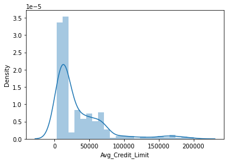

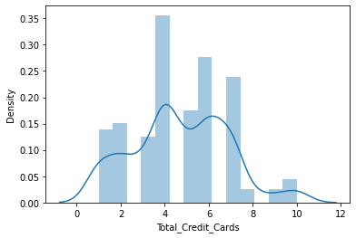

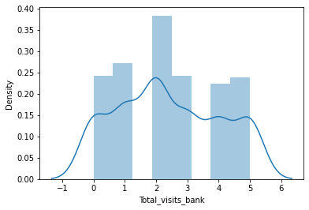

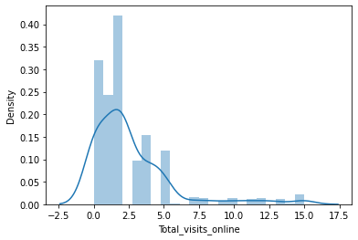

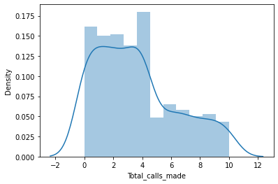

```python
#distplot for continuous columns:
for i in ['Avg_Credit_Limit','Total_Credit_Cards','Total_visits_bank','Total_visits_online','Total_calls_made']:
    sns.distplot(customer_df[i])
    plt.show()
```

#### 1. Avg_Credit_limt

#### 2. Total_Visits_Online

#### Both the above have their mean greater than mode thus both of them are positively skewed. Thus, as can be seen from the distribution curves, the outliers are on the right side i.e. upper side of the distribution curve.

```python
#Let's check Skew in all numerical attributes


Skewness = pd.DataFrame({'Skewness' : [stats.skew(customer_df.Avg_Credit_Limit),stats.skew(customer_df.Total_Credit_Cards),stats.skew(customer_df.Total_visits_bank),stats.skew(customer_df.Total_visits_online),stats.skew(customer_df.Total_calls_made)]},
                        index=['Avg_Credit_Limit','Total_Credit_Cards','Total_visits_bank','Total_visits_online','Total_calls_made'])  # Measure the skeweness of the required columns
Skewness
```

|  | Skewness |
| --- | --- |
| Avg_Credit_Limit | 2.197387 |
| Total_Credit_Cards | 0.144550 |
| Total_visits_bank | 0.141573 |
| Total_visits_online | 2.220545 |
| Total_calls_made | 0.657407 |

#### From the skewness measure above we can confirm that the distribution of variables Avg_Credit_Limit and Total_visits_online have high skeness.

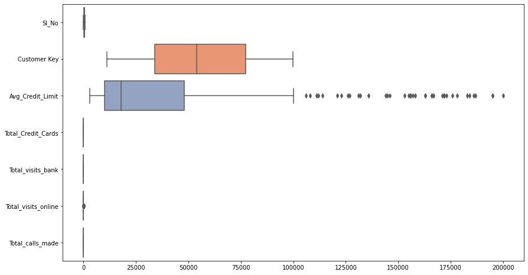

```python
plt.figure(figsize=(14,8))
sns.boxplot(data=customer_df, orient="h", palette="Set2", dodge=False)
```

#### From above boxplots we can observe the existance of outliers mainly in Avg_Credit_Limit and a very limited number of outliers in variable Total_visits_online also.

### Treating outliers in the attribute Avg_Credit_Limit:

```python
##outliers are there in the variable Avg_Credit_Limit.
outlier_columns = []

Q1 =  customer_df['Avg_Credit_Limit'].quantile(0.25) # 1st Quartile
Q3 =  customer_df['Avg_Credit_Limit'].quantile(0.75) # 3rd Quartile
IQR = Q3 - Q1                      # Interquartile range

LTV_Avg_Credit_Limit = Q1 - 1.75 * IQR   # lower bound
UTV_Avg_Credit_Limit = Q3 + 1.75 * IQR   # upper bound

print('Interquartile range = ', IQR)
print('Average Credit Limit <',LTV_Avg_Credit_Limit ,'and >',UTV_Avg_Credit_Limit, ' are outliers')
print('Number of outliers in Avg_Credit_Limit column below the lower whisker =', customer_df[customer_df['Avg_Credit_Limit'] < (Q1-(1.75*IQR))]['Avg_Credit_Limit'].count())
print('Number of outliers in Avg_Credit_Limit column above the upper whisker =', customer_df[customer_df['Avg_Credit_Limit'] > (Q3+(1.75*IQR))]['Avg_Credit_Limit'].count())

# storing column name and upper-lower bound value where outliers are presense
outlier_columns.append('Avg_Credit_Limit')
upperLowerBound_Disct = {'Average Credit Limit':UTV_Avg_Credit_Limit}
```

```
Interquartile range =  38000.0
Average Credit Limit < -56500.0 and > 114500.0  are outliers
Number of outliers in Avg_Credit_Limit column below the lower whisker = 0
Number of outliers in Avg_Credit_Limit column above the upper whisker = 34
```

#### Thus from above analysis we can see that there are 34 outliers on the upper side in Avg_Credit_Limit attribute. But there are no outliers on the left or lowers side of the data distribution.

### Treating outliers in the attribute Total_visits_online:

```python
##outliers are there in the variable Total_visits_online.
Q1 =  customer_df['Total_visits_online'].quantile(0.25) # 1st Quartile
Q3 =  customer_df['Total_visits_online'].quantile(0.75) # 3rd Quartile
IQR = Q3 - Q1                      # Interquartile range

LTV_Total_visits_online = Q1 - 1.75 * IQR   # lower bound
UTV_Total_visits_online = Q3 + 1.75 * IQR   # upper bound

print('Interquartile range = ', IQR)
print('Total visits online <',LTV_Total_visits_online ,'and >',UTV_Total_visits_online, ' are outliers')
print('Number of outliers in Total_visits_online column below the lower whisker =', customer_df[customer_df['Total_visits_online'] < (Q1-(1.75*IQR))]['Total_visits_online'].count())
print('Number of outliers in Total_visits_online column above the upper whisker =', customer_df[customer_df['Total_visits_online'] > (Q3+(1.75*IQR))]['Total_visits_online'].count())

# storing column name and upper-lower bound value where outliers are presense
outlier_columns.append('Total_visits_online')
upperLowerBound_Disct['Total_visits_online']= UTV_Total_visits_online
```

```
Interquartile range =  3.0
Total visits online < -4.25 and > 9.25  are outliers
Number of outliers in Total_visits_online column below the lower whisker = 0
Number of outliers in Total_visits_online column above the upper whisker = 33
```

#### Thus from above analysis we can see that there are 33 outliers on the upper side in total_visits_online attribute. But there are no outliers on the left or lowers side of its data distribution.

### Fixing Outliers

#### I have also shown the number of outliers presence in each column in below code.

```python
print('These are the columns which have outliers : \n\n',outlier_columns)
print('\n\n',upperLowerBound_Disct)
```

```
These are the columns which have outliers :

 ['Avg_Credit_Limit', 'Total_visits_online']


 {'Average Credit Limit': 114500.0, 'Total_visits_online': 9.25}
```

```python
customer_df.describe().transpose()
```

|  | count | mean | std | min | 25% | 50% | 75% | max |
| --- | --- | --- | --- | --- | --- | --- | --- | --- |
| Sl_No | 660.0 | 330.500000 | 190.669872 | 1.0 | 165.75 | 330.5 | 495.25 | 660.0 |
| Customer Key | 660.0 | 55141.443939 | 25627.772200 | 11265.0 | 33825.25 | 53874.5 | 77202.50 | 99843.0 |
| Avg_Credit_Limit | 660.0 | 34574.242424 | 37625.487804 | 3000.0 | 10000.00 | 18000.0 | 48000.00 | 200000.0 |
| Total_Credit_Cards | 660.0 | 4.706061 | 2.167835 | 1.0 | 3.00 | 5.0 | 6.00 | 10.0 |
| Total_visits_bank | 660.0 | 2.403030 | 1.631813 | 0.0 | 1.00 | 2.0 | 4.00 | 5.0 |
| Total_visits_online | 660.0 | 2.606061 | 2.935724 | 0.0 | 1.00 | 2.0 | 4.00 | 15.0 |
| Total_calls_made | 660.0 | 3.583333 | 2.865317 | 0.0 | 1.00 | 3.0 | 5.00 | 10.0 |

#### We can see above the max in Avg_Credit_Limit is 200000 which surely along with other data points is outliers. We will replace these outliers below and cehck again to confirm that these outliers o longer exist.

```python
for col_name in customer_df.columns[:-2]:
    q1 = customer_df[col_name].quantile(0.25)
    q3 = customer_df[col_name].quantile(0.75)
    iqr = q3 - q1
#    low = q1-1.75*iqr
    high = q3+1.5*iqr

    customer_df.loc[(customer_df[col_name] > high), col_name] = high

   # dfconcrete_new.loc[(dfconcrete_new[col_name] < low) | (dfconcrete_new[col_name] > high), col_name] = dfconcrete_new[col_name].median()
```

#### Lets look at the customer dataframe after repacing the outlieers with 'high'. We should see that the max have been replaced with 'high' to remove the out;iers.

```python
customer_df.describe().transpose()
```

|  | count | mean | std | min | 25% | 50% | 75% | max |
| --- | --- | --- | --- | --- | --- | --- | --- | --- |
| Sl_No | 660.0 | 330.500000 | 190.669872 | 1.0 | 165.75 | 330.5 | 495.25 | 660.0 |
| Customer Key | 660.0 | 55141.443939 | 25627.772200 | 11265.0 | 33825.25 | 53874.5 | 77202.50 | 99843.0 |
| Avg_Credit_Limit | 660.0 | 31666.666667 | 28506.386332 | 3000.0 | 10000.00 | 18000.0 | 48000.00 | 105000.0 |
| Total_Credit_Cards | 660.0 | 4.706061 | 2.167835 | 1.0 | 3.00 | 5.0 | 6.00 | 10.0 |
| Total_visits_bank | 660.0 | 2.403030 | 1.631813 | 0.0 | 1.00 | 2.0 | 4.00 | 5.0 |
| Total_visits_online | 660.0 | 2.606061 | 2.935724 | 0.0 | 1.00 | 2.0 | 4.00 | 15.0 |
| Total_calls_made | 660.0 | 3.583333 | 2.865317 | 0.0 | 1.00 | 3.0 | 5.00 | 10.0 |

#### From the matrix above we can see that the max of Avg_Credit_Limit is now 105000 instead of 200000 before replacement. This confirms that the outliers have been replaced.

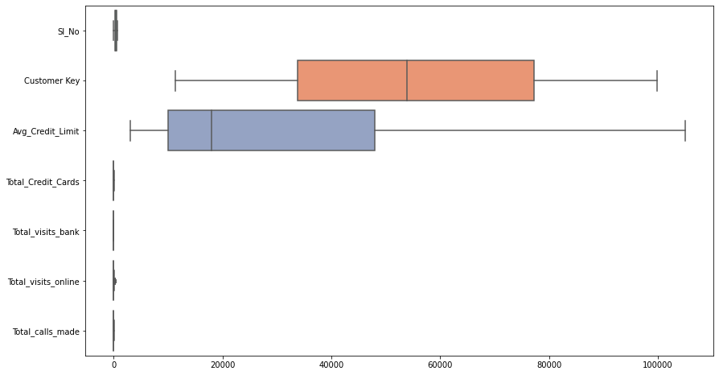

```python
plt.figure(figsize=(14,8))
sns.boxplot(data=customer_df, orient="h", palette="Set2", dodge=False)
```

## 2. Conclude your insights from the graphs

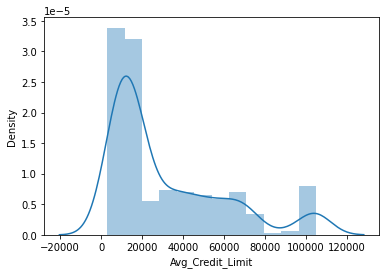

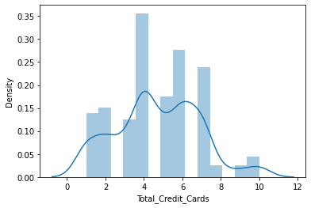

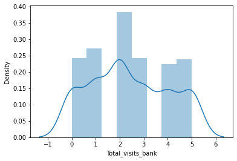

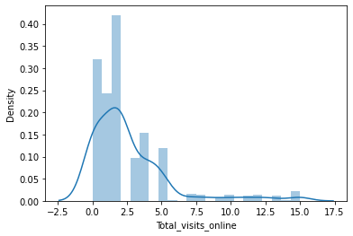

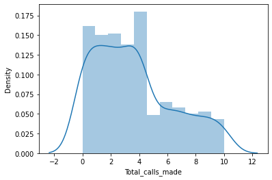

```python
#distplot for continuous columns:
for i in ['Avg_Credit_Limit','Total_Credit_Cards','Total_visits_bank','Total_visits_online','Total_calls_made']:
    sns.distplot(customer_df[i])
    plt.show()
```

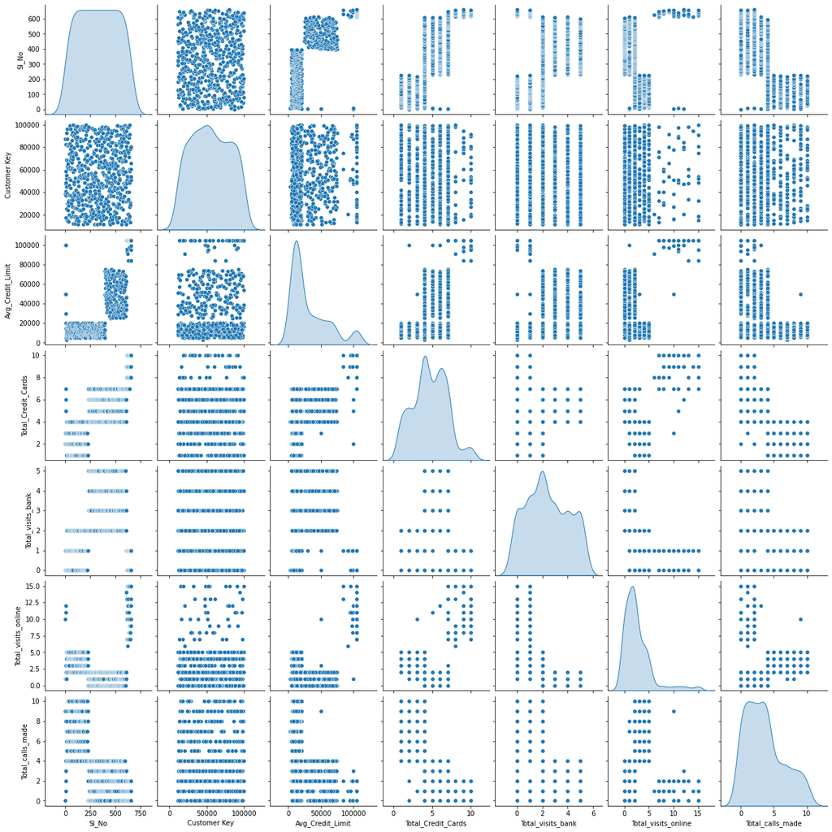

```python
sns.pairplot(customer_df,diag_kind='kde')
```

### For Scaling the customer data we will consider only those columns which have data and exclude the first two columns i.e. Sl_No and Customer_key

```python
customerAttr=customer_df.iloc[:,2:]
```

#### Standardizing the customer data using zscore method i.e. standardizing based on standard deviation of the entire data set.

```python
customerScaled=customerAttr.apply(zscore)
customerScaled
```

|  | Avg_Credit_Limit | Total_Credit_Cards | Total_visits_bank | Total_visits_online | Total_calls_made |
| --- | --- | --- | --- | --- | --- |
| 0 | 2.398942 | -1.249225 | -0.860451 | -0.547490 | -1.251537 |
| 1 | 0.643619 | -0.787585 | -1.473731 | 2.520519 | 1.891859 |
| 2 | 0.643619 | 1.058973 | -0.860451 | 0.134290 | 0.145528 |
| 3 | -0.058511 | 0.135694 | -0.860451 | -0.547490 | 0.145528 |
| 4 | 2.398942 | 0.597334 | -1.473731 | 3.202298 | -0.203739 |
| ... | ... | ... | ... | ... | ... |
| 655 | 2.363835 | 2.443892 | -0.860451 | 2.520519 | -1.251537 |
| 656 | 1.837238 | 2.443892 | -0.860451 | 3.543188 | -0.553005 |
| 657 | 2.574474 | 1.520613 | -0.860451 | 2.179629 | -0.902271 |
| 658 | 2.574474 | 2.443892 | -0.860451 | 4.224968 | -1.251537 |
| 659 | 2.574474 | 1.982253 | -1.473731 | 3.202298 | -0.553005 |

660 rows × 5 columns

## 3. Execute K-means clustering, use elbow plot and analyze clusters using boxplot

#### We will proceed here with executing K-Means clustering and in the subsequent section i.e. Section 4 we will execute various types of Hierarchical clustering. While executing K-Means and Hierarchical clustering we will be storing the output of these clustering i.e. we will be storing the Cophenet Score and Silhouette Score in a matrix. This matrix we will print at the end of section 4 which will showcase all the results in one glimpse to help us compare the performance across the various clustering methods.

```python
from sklearn import datasets
from sklearn.cluster import KMeans
```

### Group into similar Clusters

#### Here we are trying to find the optimal number of clusters for K-Means methos of clustering

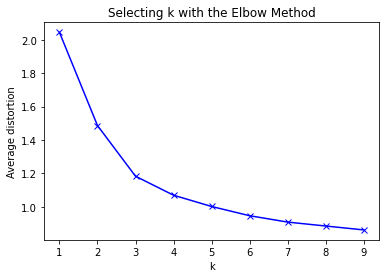

```python
from scipy.spatial.distance import cdist
clusters=range(1,10)
meanDistortions=[]

for k in clusters:
    model=KMeans(n_clusters=k)
    model.fit(customerScaled)
    prediction=model.predict(customerScaled)
    meanDistortions.append(sum(np.min(cdist(customerScaled, model.cluster_centers_, 'euclidean'), axis=1)) / customerScaled.shape[0])


plt.plot(clusters, meanDistortions, 'bx-')
plt.xlabel('k')
plt.ylabel('Average distortion')
plt.title('Selecting k with the Elbow Method')
```

#### As observed from the curve above we can see the elbow is at K=3. This indicates that the with 3 clusers we can acheive optimal seggregation / segmentation of the given customer data. We will now proceed with 3 clusters to execute K-Means clustering

```python
# Let us now start with K = 3
final_model=KMeans(3)
final_model.fit(customerScaled)
prediction=final_model.predict(customerScaled)

#Append the prediction
customer_df["GROUP"] = prediction
customerScaled["GROUP"] = prediction
print("Groups have been assigned to each row in dataset : \n")
customerScaled.head()
```

```
Groups have been assigned to each row in dataset :
```

|  | Avg_Credit_Limit | Total_Credit_Cards | Total_visits_bank | Total_visits_online | Total_calls_made | GROUP |
| --- | --- | --- | --- | --- | --- | --- |
| 0 | 2.398942 | -1.249225 | -0.860451 | -0.547490 | -1.251537 | 2 |
| 1 | 0.643619 | -0.787585 | -1.473731 | 2.520519 | 1.891859 | 1 |
| 2 | 0.643619 | 1.058973 | -0.860451 | 0.134290 | 0.145528 | 2 |
| 3 | -0.058511 | 0.135694 | -0.860451 | -0.547490 | 0.145528 | 2 |
| 4 | 2.398942 | 0.597334 | -1.473731 | 3.202298 | -0.203739 | 0 |

#### In the matrix above the 'GROUP' columns has the number of the cluster the corresponding data record has been assigned to. These three 'GROUPS' are 0, 1 and 2

### Analyze the distribution of the data among the three groups (K = 3). One of the most informative visual tool is boxplot.

```python
customerClust = customer_df.groupby(['GROUP'])
customerClust.mean()
```

| GROUP | Sl_No | Customer Key | Avg_Credit_Limit | Total_Credit_Cards | Total_visits_bank | Total_visits_online | Total_calls_made |
| --- | --- | --- | --- | --- | --- | --- | --- |
| 0 | 611.280000 | 56708.760000 | 102660.000000 | 8.740000 | 0.600000 | 10.900000 | 1.080000 |
| 1 | 117.857143 | 55239.830357 | 12174.107143 | 2.410714 | 0.933036 | 3.553571 | 6.870536 |
| 2 | 417.528497 | 54881.329016 | 33782.383420 | 5.515544 | 3.489637 | 0.981865 | 2.000000 |

```
array([[<AxesSubplot:title={'center':'Avg_Credit_Limit'}, xlabel='[GROUP]'>,
        <AxesSubplot:title={'center':'Total_Credit_Cards'}, xlabel='[GROUP]'>,
        <AxesSubplot:title={'center':'Total_calls_made'}, xlabel='[GROUP]'>,
        <AxesSubplot:title={'center':'Total_visits_bank'}, xlabel='[GROUP]'>],
       [<AxesSubplot:title={'center':'Total_visits_online'}, xlabel='[GROUP]'>,
        <AxesSubplot:>, <AxesSubplot:>, <AxesSubplot:>]], dtype=object)
```

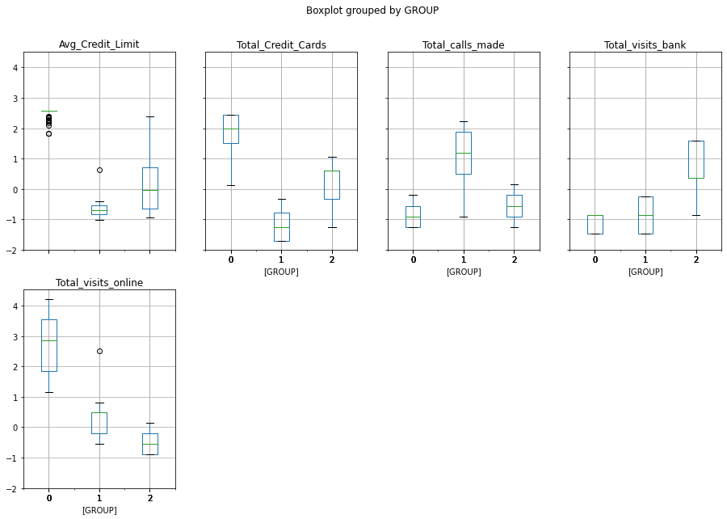

```python
customerScaled.boxplot(by='GROUP', layout = (2,4),figsize=(15,10))
```

### Analysis the box Plots

#### From the mean of the three clusters we can clearly make the following observations:

#### 1. Group 0 are the customers who have highest average credit limit. This group also has the highest number of Credit card with the average of the group being around 8 cards. And this goup has the highest online visits compared to other two groups. This group therefore has less number of visits to the bank and also least number of calls made to the bank. Thus, this group of high credit limits conducts its banking business more through internet insteaf of physical visits or telephonic calls.

#### 2. Group 1 is the cluster which comprises of customers with least average credit limit of aroundn 12K USD. This group also has the least number of average credit cards per customer of just over 2 cards. The number of average visits on line are also higherThis group makes the highest number of calls to the bank but their visits to the bank are higher than Group 0's but less than those of average total visits to the bank by Group 2.

#### 3. Group 2 is the cluster with medium level of average credit limit and medium number of credit cards owned by each customer of this group. This group also has medium level of total_calls_made i,e, it is more than those made by Group0 but less than the calls made by cystomer in group 1.

```python
# Defining a dataframe to save the values of clustering Thechnique executed, the Silhouette Score and Cophenet Score
Cluster_Technique = []
Silhouette_score = []
Cophenet_score= []
```

```python
# Calculate Avg Silhoutte Score
from sklearn.metrics import silhouette_score
score =silhouette_score(customerScaled, final_model.labels_, metric='euclidean')
#score
print("Silhouette_score of K-Means clustering", score)
```

```
Silhouette_score of K-Means clustering 0.5322482398373303
```

```python
Cluster_Technique.append('K-Means Clustering')
Silhouette_score.append(score)
Cophenet_score.append('-')
```

## 4. Execute hierarchical clustering (with different linkages) with the help of dendrogram and cophenetic coeff. Analyse clusters formed using boxplot

### 4.1 As a first method of executing Hierarchical clustering we will use 'average' as linkage and 'Eucledian' as distance

```python
# Import the Credit Card Customer Data data file
customer_df=pd.read_csv("Credit Card Customer Data.csv")
```

```python
customerAttr=customer_df.iloc[:,2:]
```

```python
# We will start with checking the dataset which we got after excluding the first two columns i.e. Sl_No and Customer_key
customerAttr
```

|  | Avg_Credit_Limit | Total_Credit_Cards | Total_visits_bank | Total_visits_online | Total_calls_made |
| --- | --- | --- | --- | --- | --- |
| 0 | 100000 | 2 | 1 | 1 | 0 |
| 1 | 50000 | 3 | 0 | 10 | 9 |
| 2 | 50000 | 7 | 1 | 3 | 4 |
| 3 | 30000 | 5 | 1 | 1 | 4 |
| 4 | 100000 | 6 | 0 | 12 | 3 |
| ... | ... | ... | ... | ... | ... |
| 655 | 99000 | 10 | 1 | 10 | 0 |
| 656 | 84000 | 10 | 1 | 13 | 2 |
| 657 | 145000 | 8 | 1 | 9 | 1 |
| 658 | 172000 | 10 | 1 | 15 | 0 |
| 659 | 167000 | 9 | 0 | 12 | 2 |

660 rows × 5 columns

```python
# Now we we are standardizing the 'customerattr' data using zscore
customerScaled=customerAttr.apply(zscore)
customerScaled
```

|  | Avg_Credit_Limit | Total_Credit_Cards | Total_visits_bank | Total_visits_online | Total_calls_made |
| --- | --- | --- | --- | --- | --- |
| 0 | 1.740187 | -1.249225 | -0.860451 | -0.547490 | -1.251537 |
| 1 | 0.410293 | -0.787585 | -1.473731 | 2.520519 | 1.891859 |
| 2 | 0.410293 | 1.058973 | -0.860451 | 0.134290 | 0.145528 |
| 3 | -0.121665 | 0.135694 | -0.860451 | -0.547490 | 0.145528 |
| 4 | 1.740187 | 0.597334 | -1.473731 | 3.202298 | -0.203739 |
| ... | ... | ... | ... | ... | ... |
| 655 | 1.713589 | 2.443892 | -0.860451 | 2.520519 | -1.251537 |
| 656 | 1.314621 | 2.443892 | -0.860451 | 3.543188 | -0.553005 |
| 657 | 2.937092 | 1.520613 | -0.860451 | 2.179629 | -0.902271 |
| 658 | 3.655235 | 2.443892 | -0.860451 | 4.224968 | -1.251537 |
| 659 | 3.522245 | 1.982253 | -1.473731 | 3.202298 | -0.553005 |

660 rows × 5 columns

```python
from sklearn.cluster import AgglomerativeClustering
```

```python
# We are executing Agglomerative hierarchical clustering with 'average' as linkage type and 'eucledian' as distance dtermination method
model = AgglomerativeClustering(n_clusters=3, affinity='euclidean',  linkage='average')
```

```python
model.fit(customerScaled)
```

```
AgglomerativeClustering(affinity='euclidean', compute_full_tree='auto',
                        connectivity=None, distance_threshold=None,
                        linkage='average', memory=None, n_clusters=3)
```

```python
# We are appending column 'labels' which has the group no. to which the correspoding row of data belongs or is assigned to.
customerAttr['labels'] = model.labels_
customerScaled['labels'] = model.labels_
customerScaled.head(10)

#customerAttr.groupby(["labels"]).count()
```

|  | Avg_Credit_Limit | Total_Credit_Cards | Total_visits_bank | Total_visits_online | Total_calls_made | labels |
| --- | --- | --- | --- | --- | --- | --- |
| 0 | 1.740187 | -1.249225 | -0.860451 | -0.547490 | -1.251537 | 0 |
| 1 | 0.410293 | -0.787585 | -1.473731 | 2.520519 | 1.891859 | 2 |
| 2 | 0.410293 | 1.058973 | -0.860451 | 0.134290 | 0.145528 | 0 |
| 3 | -0.121665 | 0.135694 | -0.860451 | -0.547490 | 0.145528 | 0 |
| 4 | 1.740187 | 0.597334 | -1.473731 | 3.202298 | -0.203739 | 1 |
| 5 | -0.387644 | -0.787585 | -1.473731 | -0.547490 | 1.542593 | 2 |
| 6 | 1.740187 | 0.135694 | -1.473731 | 2.861408 | -0.553005 | 1 |
| 7 | -0.520633 | -0.787585 | -1.473731 | -0.547490 | -0.902271 | 2 |
| 8 | -0.786612 | -1.249225 | -1.473731 | -0.206600 | -0.553005 | 2 |
| 9 | -0.839808 | -0.325946 | -1.473731 | -0.547490 | 1.193326 | 2 |

```python
customerClust = customerScaled.groupby(['labels'])
```

```python
customerClust.mean()
```

| labels | Avg_Credit_Limit | Total_Credit_Cards | Total_visits_bank | Total_visits_online | Total_calls_made |
| --- | --- | --- | --- | --- | --- |
| 0 | -0.022902 | 0.371882 | 0.664034 | -0.552775 | -0.551200 |
| 1 | 2.831764 | 1.862226 | -1.105763 | 2.827319 | -0.874330 |
| 2 | -0.595179 | -1.062913 | -0.904453 | 0.325372 | 1.152605 |

```
array([[<AxesSubplot:title={'center':'Avg_Credit_Limit'}, xlabel='[labels]'>,
        <AxesSubplot:title={'center':'Total_Credit_Cards'}, xlabel='[labels]'>,
        <AxesSubplot:title={'center':'Total_calls_made'}, xlabel='[labels]'>,
        <AxesSubplot:title={'center':'Total_visits_bank'}, xlabel='[labels]'>],
       [<AxesSubplot:title={'center':'Total_visits_online'}, xlabel='[labels]'>,
        <AxesSubplot:>, <AxesSubplot:>, <AxesSubplot:>]], dtype=object)
```

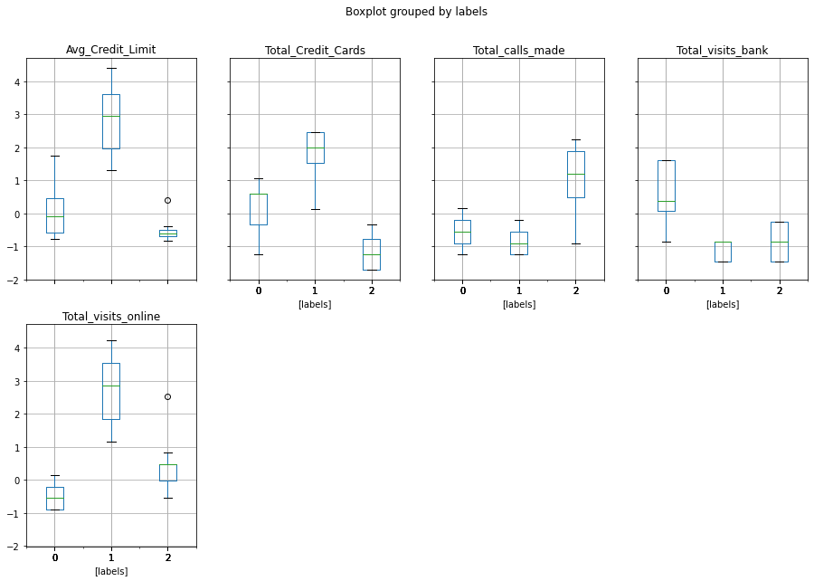

```python
customerScaled.boxplot(by='labels', layout = (2,4),figsize=(15,10))
```

### Analysis the box Plots

#### From the mean of the three clusters we can make the following observations, which are similar to that of analysis of K-Means clustering box-plots except that the Group number are swapped wrt those of K-Means clustering:

#### 1. Group 0 is the cluster with medium level of average credit limit and medium number of credit cards owned by each customer of this group. This group alos has medium level of total_calls_made i,e, it is more than those made by Group1 but less than the calls made by cystomer in group 2.

#### 2. Group 1 are the customers who have highest average credit limit. This group also has the highest number of Credit cards. And this goup has the highest online visits compared to other two groups. This groupd therefore has less number of visits to the bank and also least number of calls made to the bank. Thus, this group of high credit limits conducts its banking business more through internet insteaf of physical visits or telephonic calls.

#### 3. Group 2 is the cluster which comprises of customers with least average credit limit. This group also has the least number of average credit cards per customer of just over 2 cards. The number of average visits on line are also higherThis group makes the highest number of calls to the bank but their visits to the bank are higher than Group 1's but less than those of average total visits to the bank by Group 0.

```python
from scipy.cluster.hierarchy import cophenet, dendrogram, linkage
```

```python
from scipy.spatial.distance import pdist  #Pairwise distribution between data points
```

```python
# cophenet index is a measure of the correlation between the distance of points in feature space and distance on dendrogram
# closer it is to 1, the better is the clustering

Z = linkage(customerScaled, metric='euclidean', method='average')
c, coph_dists = cophenet(Z , pdist(customerScaled))

print("Cophenet Index of hierarchical clustering for 'average' method and 'euclidean' metric",c)
```

```
Cophenet Index of hierarchical clustering for 'average' method and 'euclidean' metric 0.9252387749820263
```

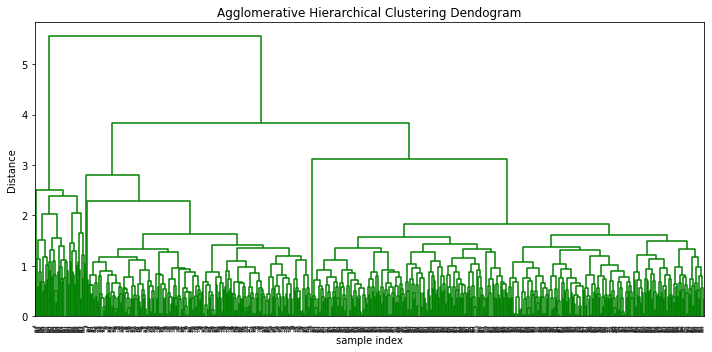

```python
plt.figure(figsize=(10, 5))
plt.title('Agglomerative Hierarchical Clustering Dendogram')
plt.xlabel('sample index')
plt.ylabel('Distance')
dendrogram(Z, leaf_rotation=90.,color_threshold = 40, leaf_font_size=4. )
plt.tight_layout()
```

### From the truncated dendogram, find out the optimal distance between the clusters which you want to use as an input for clustering the data

### Here we are first truncating the dendrogram at 5 branches / clusters and then we will analyze

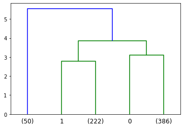

```python
#Hint: Use truncate_mode='lastp' attribute in dendogram function to arrive at dendogram
dendrogram(
    Z,
    truncate_mode='lastp', # shpw only the last p merged clusters
    p=5,                   # shpw only the last p merged clusters
)
plt.show()
```

### From the above dendrogram we can see that when truncated for 5 clusters 2 of these clusters combined have only 1 row. So its better to instead truncate at 3 clusters

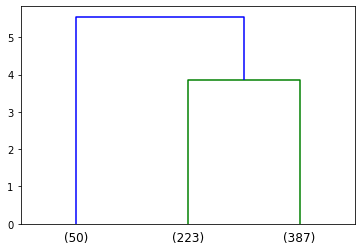

```python
#Hint: Use truncate_mode='lastp' attribute in dendogram function to arrive at dendogram
dendrogram(
    Z,
    truncate_mode='lastp', # show only the last p merged clusters
    p=3,                   # show only the last p merged clusters
)
plt.show()
```

```python
max_d=3.2
```

### Use this distance measure(max_d) and fcluster function to cluster the data into 3 different groups

```python
from scipy.cluster.hierarchy import fcluster
clusters = fcluster(Z, max_d, criterion='distance')
clusters
```

```
array([3, 2, 3, 3, 1, 2, 1, 2, 2, 2, 2, 2, 2, 2, 2, 2, 2, 2, 2, 2, 2, 2,
       2, 2, 2, 2, 2, 2, 2, 2, 2, 2, 2, 2, 2, 2, 2, 2, 2, 2, 2, 2, 2, 2,
       2, 2, 2, 2, 2, 2, 2, 2, 2, 2, 2, 2, 2, 2, 2, 2, 2, 2, 2, 2, 2, 2,
       2, 2, 2, 2, 2, 2, 2, 2, 2, 2, 2, 2, 2, 2, 2, 2, 2, 2, 2, 2, 2, 2,
       2, 2, 2, 2, 2, 2, 2, 2, 2, 2, 2, 2, 2, 2, 2, 2, 2, 2, 2, 2, 2, 2,
       2, 2, 2, 2, 2, 2, 2, 2, 2, 2, 2, 2, 2, 2, 2, 2, 2, 2, 2, 2, 2, 2,
       2, 2, 2, 2, 2, 2, 2, 2, 2, 2, 2, 2, 2, 2, 2, 2, 2, 2, 2, 2, 2, 2,
       2, 2, 2, 2, 2, 2, 2, 2, 2, 2, 2, 2, 2, 2, 2, 2, 2, 2, 2, 2, 2, 2,
       2, 2, 2, 2, 2, 2, 2, 2, 2, 2, 2, 2, 2, 2, 2, 2, 2, 2, 2, 2, 2, 2,
       2, 2, 2, 2, 2, 2, 2, 2, 2, 2, 2, 2, 2, 2, 2, 2, 2, 2, 2, 2, 2, 2,
       2, 2, 2, 2, 2, 2, 2, 2, 3, 3, 3, 3, 3, 3, 3, 3, 3, 3, 3, 3, 3, 3,
       3, 3, 3, 3, 3, 3, 3, 3, 3, 3, 3, 3, 3, 3, 3, 3, 3, 3, 3, 3, 3, 3,
       3, 3, 3, 3, 3, 3, 3, 3, 3, 3, 3, 3, 3, 3, 3, 3, 3, 3, 3, 3, 3, 3,
       3, 3, 3, 3, 3, 3, 3, 3, 3, 3, 3, 3, 3, 3, 3, 3, 3, 3, 3, 3, 3, 3,
       3, 3, 3, 3, 3, 3, 3, 3, 3, 3, 3, 3, 3, 3, 3, 3, 3, 3, 3, 3, 3, 3,
```

[output cut: 16 more lines]

```python
# Calculate Avg Silhoutte Score

from sklearn.metrics import silhouette_score
silhouette_score(customerScaled,clusters)
print("Silhouette_score of hierarhy clustering with 'average' linkage and 'euclidean' metric is:", silhouette_score(customerScaled,clusters))
```

```
Silhouette_score of hierarhy clustering with 'average' linkage and 'euclidean' metric is: 0.590990473596407
```

```python
Cluster_Technique.append('hierarchy Clustering average, eucledian')
Silhouette_score.append(silhouette_score(customerScaled,clusters))
Cophenet_score.append(c)
```

### 4.2 As a second method of executing Hierarchical clustering we will use 'ward' as linkage and 'Eucledian' as distance

```python
customerAttr
```

|  | Avg_Credit_Limit | Total_Credit_Cards | Total_visits_bank | Total_visits_online | Total_calls_made | labels |
| --- | --- | --- | --- | --- | --- | --- |
| 0 | 100000 | 2 | 1 | 1 | 0 | 0 |
| 1 | 50000 | 3 | 0 | 10 | 9 | 2 |
| 2 | 50000 | 7 | 1 | 3 | 4 | 0 |
| 3 | 30000 | 5 | 1 | 1 | 4 | 0 |
| 4 | 100000 | 6 | 0 | 12 | 3 | 1 |
| ... | ... | ... | ... | ... | ... | ... |
| 655 | 99000 | 10 | 1 | 10 | 0 | 1 |
| 656 | 84000 | 10 | 1 | 13 | 2 | 1 |
| 657 | 145000 | 8 | 1 | 9 | 1 | 1 |
| 658 | 172000 | 10 | 1 | 15 | 0 | 1 |
| 659 | 167000 | 9 | 0 | 12 | 2 | 1 |

660 rows × 6 columns

```python
# Let's drop the column labels which we added to customerattr
customerAttr = customerAttr.drop('labels', axis=1)
```

```python
# Here we are standardizing the data using zscore
customerScaled=customerAttr.apply(zscore)
customerScaled
```

|  | Avg_Credit_Limit | Total_Credit_Cards | Total_visits_bank | Total_visits_online | Total_calls_made |
| --- | --- | --- | --- | --- | --- |
| 0 | 1.740187 | -1.249225 | -0.860451 | -0.547490 | -1.251537 |
| 1 | 0.410293 | -0.787585 | -1.473731 | 2.520519 | 1.891859 |
| 2 | 0.410293 | 1.058973 | -0.860451 | 0.134290 | 0.145528 |
| 3 | -0.121665 | 0.135694 | -0.860451 | -0.547490 | 0.145528 |
| 4 | 1.740187 | 0.597334 | -1.473731 | 3.202298 | -0.203739 |
| ... | ... | ... | ... | ... | ... |
| 655 | 1.713589 | 2.443892 | -0.860451 | 2.520519 | -1.251537 |
| 656 | 1.314621 | 2.443892 | -0.860451 | 3.543188 | -0.553005 |
| 657 | 2.937092 | 1.520613 | -0.860451 | 2.179629 | -0.902271 |
| 658 | 3.655235 | 2.443892 | -0.860451 | 4.224968 | -1.251537 |
| 659 | 3.522245 | 1.982253 | -1.473731 | 3.202298 | -0.553005 |

660 rows × 5 columns

### Use 'ward' as linkage metric and distance as 'eucledian'

```python
model = AgglomerativeClustering(n_clusters=3, affinity='euclidean',  linkage='ward')
```

```python
model.fit(customerScaled)
```

```
AgglomerativeClustering(affinity='euclidean', compute_full_tree='auto',
                        connectivity=None, distance_threshold=None,
                        linkage='ward', memory=None, n_clusters=3)
```

```python
customerAttr['labels'] = model.labels_
customerScaled['labels'] = model.labels_
customerScaled.head(10)

#customerAttr.groupby(["labels"]).count()
```

|  | Avg_Credit_Limit | Total_Credit_Cards | Total_visits_bank | Total_visits_online | Total_calls_made | labels |
| --- | --- | --- | --- | --- | --- | --- |
| 0 | 1.740187 | -1.249225 | -0.860451 | -0.547490 | -1.251537 | 0 |
| 1 | 0.410293 | -0.787585 | -1.473731 | 2.520519 | 1.891859 | 1 |
| 2 | 0.410293 | 1.058973 | -0.860451 | 0.134290 | 0.145528 | 0 |
| 3 | -0.121665 | 0.135694 | -0.860451 | -0.547490 | 0.145528 | 0 |
| 4 | 1.740187 | 0.597334 | -1.473731 | 3.202298 | -0.203739 | 2 |
| 5 | -0.387644 | -0.787585 | -1.473731 | -0.547490 | 1.542593 | 1 |
| 6 | 1.740187 | 0.135694 | -1.473731 | 2.861408 | -0.553005 | 2 |
| 7 | -0.520633 | -0.787585 | -1.473731 | -0.547490 | -0.902271 | 1 |
| 8 | -0.786612 | -1.249225 | -1.473731 | -0.206600 | -0.553005 | 1 |
| 9 | -0.839808 | -0.325946 | -1.473731 | -0.547490 | 1.193326 | 1 |

```python
customerClust = customerScaled.groupby(['labels'])
```

```python
customerClust.mean()
```

| labels | Avg_Credit_Limit | Total_Credit_Cards | Total_visits_bank | Total_visits_online | Total_calls_made |
| --- | --- | --- | --- | --- | --- |
| 0 | -0.019212 | 0.374308 | 0.668767 | -0.554573 | -0.554819 |
| 1 | -0.596408 | -1.054310 | -0.898610 | 0.320643 | 1.143653 |
| 2 | 2.831764 | 1.862226 | -1.105763 | 2.827319 | -0.874330 |

```
array([[<AxesSubplot:title={'center':'Avg_Credit_Limit'}, xlabel='[labels]'>,
        <AxesSubplot:title={'center':'Total_Credit_Cards'}, xlabel='[labels]'>,
        <AxesSubplot:title={'center':'Total_calls_made'}, xlabel='[labels]'>,
        <AxesSubplot:title={'center':'Total_visits_bank'}, xlabel='[labels]'>],
       [<AxesSubplot:title={'center':'Total_visits_online'}, xlabel='[labels]'>,
        <AxesSubplot:>, <AxesSubplot:>, <AxesSubplot:>]], dtype=object)
```

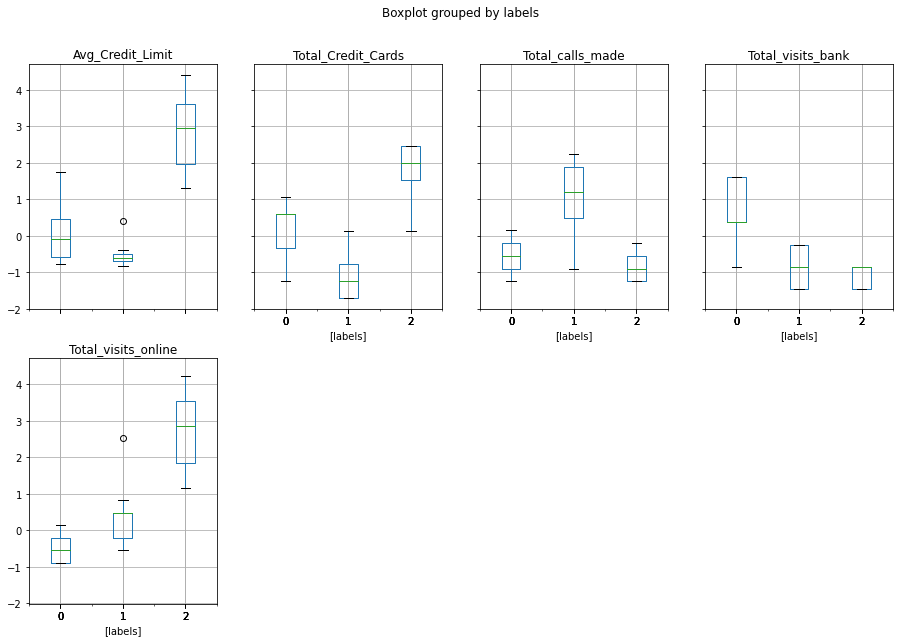

```python
customerScaled.boxplot(by='labels', layout = (2,4),figsize=(15,10))
```

### Analysis the box Plots

#### From the mean of the three clusters we can make the following observations, which are similar to that of analysis of K-Means clustering box-plots except that the Group number are swapped wrt those of K-Means clustering:

#### 1. Group 0 is the cluster with medium level of average credit limit and medium number of credit cards owned by each customer of this group. This group also has medium level of total_calls_made i,e, it is more than those made by Group2 but less than the calls made by cystomer in group 1. This group makes the highest total_visits_bank

#### 2. Group 1 is the cluster which comprises of customers with least average credit limit. This group also has the least number of average credit cards. The number of average visits on line are also higher that of Group 0's total_visits_online but less then the onlne visits of Group2. This group makes the highest number of calls to the bank but their visits to the bank are higher than Group 2's but less than those of average total visits to the bank by Group 0.

#### 3. Group 2 are the customers who have highest average credit limit. This group also has the highest number of Credit cards. And this goup has the highest online visits compared to other two groups. This groupd therefore has less number of visits to the bank and also least number of calls made to the bank. Thus, this group of high credit limits conducts its banking business more through internet insteaf of physical visits or telephonic calls.

```python
# cophenet index is a measure of the correlation between the distance of points in feature space and distance on dendrogram
# closer it is to 1, the better is the clustering

Z = linkage(customerScaled, metric='euclidean', method='ward')
c, coph_dists = cophenet(Z , pdist(customerScaled))

print("cophenet index score for hierarchical clustering with 'ward' linkage and 'euclidean' metric is:",c)
```

```
cophenet index score for hierarchical clustering with 'ward' linkage and 'euclidean' metric is: 0.7733381987448996
```

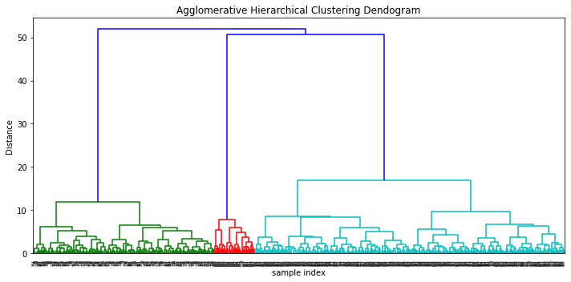

```python
plt.figure(figsize=(10, 5))
plt.title('Agglomerative Hierarchical Clustering Dendogram')
plt.xlabel('sample index')
plt.ylabel('Distance')
dendrogram(Z, leaf_rotation=90.,color_threshold = 40, leaf_font_size=4. )
plt.tight_layout()
```

### From the truncated dendogram, find out the optimal distance between the clusters which you want to use as an input for clustering the data

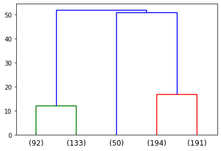

```python
#Hint: Use truncate_mode='lastp' attribute in dendogram function to arrive at dendogram
dendrogram(
    Z,
    truncate_mode='lastp', # shpw only the last p merged clusters
    p=5,                   # shpw only the last p merged clusters
)
plt.show()
```

```python
max_d=11
```

```python
from scipy.cluster.hierarchy import fcluster
clusters = fcluster(Z, max_d, criterion='distance')
clusters
```

```
array([5, 1, 5, 5, 3, 2, 3, 2, 2, 2, 2, 2, 1, 2, 2, 1, 2, 2, 2, 2, 2, 1,
       2, 2, 1, 1, 1, 1, 2, 2, 2, 2, 1, 2, 1, 2, 1, 2, 1, 1, 1, 2, 2, 2,
       2, 1, 2, 2, 2, 2, 1, 2, 1, 1, 1, 2, 2, 1, 1, 1, 2, 1, 2, 2, 1, 2,
       1, 2, 1, 1, 1, 2, 2, 2, 1, 2, 1, 2, 1, 2, 1, 2, 2, 2, 2, 2, 2, 2,
       1, 1, 2, 1, 2, 1, 2, 1, 2, 2, 1, 2, 2, 1, 1, 1, 1, 1, 2, 2, 2, 1,
       2, 1, 1, 2, 2, 2, 1, 2, 2, 1, 2, 1, 2, 1, 2, 2, 1, 1, 2, 2, 2, 2,
       2, 1, 2, 2, 2, 1, 1, 1, 2, 2, 2, 2, 1, 2, 1, 2, 1, 2, 1, 2, 2, 2,
       1, 2, 2, 1, 1, 2, 1, 2, 2, 1, 2, 1, 2, 2, 1, 2, 2, 2, 2, 1, 2, 2,
       2, 1, 1, 2, 2, 1, 2, 1, 2, 2, 2, 2, 2, 2, 1, 2, 2, 1, 2, 1, 1, 2,
       1, 1, 1, 1, 1, 1, 2, 2, 2, 2, 1, 1, 2, 2, 2, 1, 1, 2, 2, 2, 2, 1,
       1, 2, 1, 1, 1, 2, 1, 2, 5, 5, 4, 5, 4, 5, 4, 4, 4, 4, 5, 5, 5, 4,
       4, 4, 5, 5, 4, 5, 4, 4, 5, 5, 4, 5, 4, 4, 5, 4, 5, 4, 4, 5, 4, 5,
       4, 4, 4, 4, 4, 4, 4, 5, 5, 4, 4, 5, 4, 4, 4, 4, 4, 5, 5, 4, 5, 4,
       4, 5, 2, 4, 5, 5, 5, 5, 4, 4, 4, 4, 4, 4, 4, 4, 5, 4, 4, 4, 5, 5,
       4, 4, 4, 5, 5, 2, 5, 5, 4, 4, 4, 5, 4, 4, 5, 5, 4, 4, 4, 4, 4, 4,
```

[output cut: 16 more lines]

```python
# Calculate Avg Silhoutte Score

from sklearn.metrics import silhouette_score
silhouette_score(customerScaled,clusters)
print("Silhouette_score of hierarhy clustering for method 'ward' and metric 'euclidean'", silhouette_score(customerScaled,clusters))
```

```
Silhouette_score of hierarhy clustering for method 'ward' and metric 'euclidean' 0.2615224909080938
```

```python
Cluster_Technique.append('hierarchy Clustering- ward, eucledian')
Silhouette_score.append(silhouette_score(customerScaled,clusters))
Cophenet_score.append(c)
```

### 4.3 As a third method of executing Hierarchical clustering we will use 'complete' as linkage and 'chebyshev' as distance

```python
customerAttr
```

|  | Avg_Credit_Limit | Total_Credit_Cards | Total_visits_bank | Total_visits_online | Total_calls_made | labels |
| --- | --- | --- | --- | --- | --- | --- |
| 0 | 100000 | 2 | 1 | 1 | 0 | 0 |
| 1 | 50000 | 3 | 0 | 10 | 9 | 1 |
| 2 | 50000 | 7 | 1 | 3 | 4 | 0 |
| 3 | 30000 | 5 | 1 | 1 | 4 | 0 |
| 4 | 100000 | 6 | 0 | 12 | 3 | 2 |
| ... | ... | ... | ... | ... | ... | ... |
| 655 | 99000 | 10 | 1 | 10 | 0 | 2 |
| 656 | 84000 | 10 | 1 | 13 | 2 | 2 |
| 657 | 145000 | 8 | 1 | 9 | 1 | 2 |
| 658 | 172000 | 10 | 1 | 15 | 0 | 2 |
| 659 | 167000 | 9 | 0 | 12 | 2 | 2 |

660 rows × 6 columns

```python
# Let's drop the column labels which we added to customerattr
customerAttr = customerAttr.drop('labels', axis=1)
```

```python
# Here we are standardizing the data using zscore
customerScaled=customerAttr.apply(zscore)
customerScaled
```

|  | Avg_Credit_Limit | Total_Credit_Cards | Total_visits_bank | Total_visits_online | Total_calls_made |
| --- | --- | --- | --- | --- | --- |
| 0 | 1.740187 | -1.249225 | -0.860451 | -0.547490 | -1.251537 |
| 1 | 0.410293 | -0.787585 | -1.473731 | 2.520519 | 1.891859 |
| 2 | 0.410293 | 1.058973 | -0.860451 | 0.134290 | 0.145528 |
| 3 | -0.121665 | 0.135694 | -0.860451 | -0.547490 | 0.145528 |
| 4 | 1.740187 | 0.597334 | -1.473731 | 3.202298 | -0.203739 |
| ... | ... | ... | ... | ... | ... |
| 655 | 1.713589 | 2.443892 | -0.860451 | 2.520519 | -1.251537 |
| 656 | 1.314621 | 2.443892 | -0.860451 | 3.543188 | -0.553005 |
| 657 | 2.937092 | 1.520613 | -0.860451 | 2.179629 | -0.902271 |
| 658 | 3.655235 | 2.443892 | -0.860451 | 4.224968 | -1.251537 |
| 659 | 3.522245 | 1.982253 | -1.473731 | 3.202298 | -0.553005 |

660 rows × 5 columns

### Use 'complete' as linkage metric and distance as 'chebyshev'

```python
model = AgglomerativeClustering(n_clusters=3, affinity='chebyshev',  linkage='complete')
```

```python
model.fit(customerScaled)
```

```
AgglomerativeClustering(affinity='chebyshev', compute_full_tree='auto',
                        connectivity=None, distance_threshold=None,
                        linkage='complete', memory=None, n_clusters=3)
```

```python
customerAttr['labels'] = model.labels_
customerScaled['labels'] = model.labels_
customerScaled.head(10)
```

|  | Avg_Credit_Limit | Total_Credit_Cards | Total_visits_bank | Total_visits_online | Total_calls_made | labels |
| --- | --- | --- | --- | --- | --- | --- |
| 0 | 1.740187 | -1.249225 | -0.860451 | -0.547490 | -1.251537 | 2 |
| 1 | 0.410293 | -0.787585 | -1.473731 | 2.520519 | 1.891859 | 1 |
| 2 | 0.410293 | 1.058973 | -0.860451 | 0.134290 | 0.145528 | 2 |
| 3 | -0.121665 | 0.135694 | -0.860451 | -0.547490 | 0.145528 | 2 |
| 4 | 1.740187 | 0.597334 | -1.473731 | 3.202298 | -0.203739 | 0 |
| 5 | -0.387644 | -0.787585 | -1.473731 | -0.547490 | 1.542593 | 1 |
| 6 | 1.740187 | 0.135694 | -1.473731 | 2.861408 | -0.553005 | 0 |
| 7 | -0.520633 | -0.787585 | -1.473731 | -0.547490 | -0.902271 | 2 |
| 8 | -0.786612 | -1.249225 | -1.473731 | -0.206600 | -0.553005 | 2 |
| 9 | -0.839808 | -0.325946 | -1.473731 | -0.547490 | 1.193326 | 1 |

```python
customerClust = customerScaled.groupby(['labels'])
```

```python
customerClust.mean()
```

| labels | Avg_Credit_Limit | Total_Credit_Cards | Total_visits_bank | Total_visits_online | Total_calls_made |
| --- | --- | --- | --- | --- | --- |
| 0 | 2.831764 | 1.862226 | -1.105763 | 2.827319 | -0.874330 |
| 1 | -0.586653 | -1.084353 | -0.959014 | 0.371695 | 1.729699 |
| 2 | -0.152376 | 0.056900 | 0.326702 | -0.367462 | -0.301225 |

```python
# cophenet index is a measure of the correlation between the distance of points in feature space and distance on dendrogram
# closer it is to 1, the better is the clustering

Z = linkage(customerScaled, metric='chebyshev', method='complete')
c, coph_dists = cophenet(Z , pdist(customerScaled))

print("cophenet index score for hierarchical clustering with 'complete' linkage and 'chebyshev' metric is:",c)
```

```
cophenet index score for hierarchical clustering with 'complete' linkage and 'chebyshev' metric is: 0.878121018573447
```

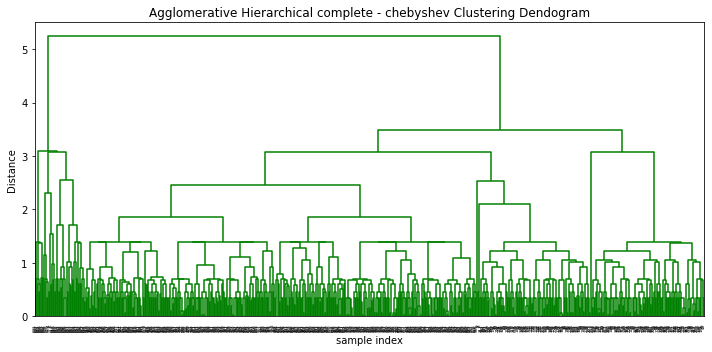

```python
plt.figure(figsize=(10, 5))
plt.title('Agglomerative Hierarchical complete - chebyshev Clustering Dendogram')
plt.xlabel('sample index')
plt.ylabel('Distance')
dendrogram(Z, leaf_rotation=90.,color_threshold = 40, leaf_font_size=4. )
plt.tight_layout()
```

### From the truncated dendogram, find out the optimal distance between the clusters which you want to use as an input for clustering the data

#### From analyzing the the dendrogram above it would be an optimal approach to truncate at 3 clusters

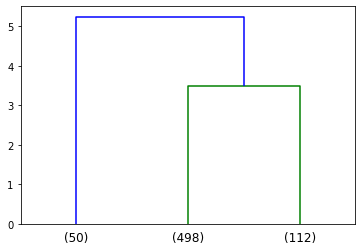

```python
#Hint: Use truncate_mode='lastp' attribute in dendogram function to arrive at dendogram
dendrogram(
    Z,
    truncate_mode='lastp', # shpw only the last p merged clusters
    p=3,                   # shpw only the last p merged clusters
)
plt.show()
```

```python
max_d=3.4
```

### Use this distance measure(max_d) and fcluster function to cluster the data into 3 different groups

```python
from scipy.cluster.hierarchy import fcluster
clusters = fcluster(Z, max_d, criterion='distance')
clusters
```

```
array([2, 3, 2, 2, 1, 3, 1, 2, 2, 3, 2, 3, 3, 2, 2, 2, 2, 2, 2, 3, 2, 2,
       2, 2, 3, 3, 3, 3, 2, 3, 2, 2, 3, 2, 3, 2, 3, 2, 3, 3, 3, 3, 2, 2,
       2, 3, 2, 2, 3, 2, 3, 2, 3, 3, 3, 2, 2, 3, 3, 3, 3, 3, 2, 2, 3, 2,
       2, 2, 3, 2, 3, 2, 2, 2, 3, 2, 2, 2, 3, 3, 3, 2, 2, 2, 2, 2, 2, 2,
       3, 3, 2, 3, 2, 3, 2, 3, 2, 2, 3, 2, 2, 3, 3, 3, 3, 3, 2, 2, 2, 3,
       2, 3, 3, 2, 2, 2, 3, 3, 2, 3, 2, 3, 2, 3, 2, 2, 3, 3, 2, 2, 2, 2,
       2, 3, 3, 2, 3, 3, 3, 3, 3, 2, 3, 2, 3, 2, 3, 2, 3, 3, 3, 2, 2, 2,
       3, 2, 3, 3, 3, 2, 3, 2, 2, 3, 3, 3, 3, 2, 3, 3, 3, 2, 2, 3, 2, 2,
       2, 3, 3, 2, 2, 3, 3, 3, 2, 2, 2, 3, 2, 2, 3, 2, 2, 3, 2, 3, 3, 3,
       3, 3, 3, 3, 3, 2, 2, 2, 2, 2, 3, 3, 2, 2, 2, 3, 3, 3, 2, 2, 3, 3,
       3, 2, 3, 3, 3, 2, 3, 3, 2, 2, 2, 2, 2, 2, 2, 2, 2, 2, 2, 2, 2, 2,
       2, 2, 2, 2, 2, 2, 2, 2, 2, 2, 2, 2, 2, 2, 2, 2, 2, 2, 2, 2, 2, 2,
       2, 2, 2, 2, 2, 2, 2, 2, 2, 2, 2, 2, 2, 2, 2, 2, 2, 2, 2, 2, 2, 2,
       2, 2, 2, 2, 2, 2, 2, 2, 2, 2, 2, 2, 2, 2, 2, 2, 2, 2, 2, 2, 2, 2,
       2, 2, 2, 2, 2, 2, 2, 2, 2, 2, 2, 2, 2, 2, 2, 2, 2, 2, 2, 2, 2, 2,
```

[output cut: 16 more lines]

```python
# Calculate Avg Silhoutte Score

from sklearn.metrics import silhouette_score
silhouette_score(customerScaled,clusters)
print("Silhouette_score of hierarhy clustering with 'complete' linkage and 'chebyshev' metric is:", silhouette_score(customerScaled,clusters))
```

```
Silhouette_score of hierarhy clustering with 'complete' linkage and 'chebyshev' metric is: 0.4043480742710366
```

```python
Cluster_Technique.append('hierarchy Clustering complete, chebyshev')
Silhouette_score.append(silhouette_score(customerScaled,clusters))
Cophenet_score.append(c)
```

## 5. Calculate average silhouette score for both methods.

### In the matrix below are given Silhouette scores for K-Means clustering and for various types of Hierarchical clustering

##### The Silhouette scores have been calculated in the previous section i.e. Section 4.

```python
compare_lr_model_df = pd.DataFrame({'Cluster_Technique': Cluster_Technique,
                               'Silhouette_score': Silhouette_score,
                               'Cophenet_score': Cophenet_score})
compare_lr_model_df
```

|  | Cluster_Technique | Silhouette_score | Cophenet_score |
| --- | --- | --- | --- |
| 0 | K-Means Clustering | 0.532248 | - |
| 1 | hierarchy Clustering average, eucledian | 0.590990 | 0.925239 |
| 2 | hierarchy Clustering- ward, eucledian | 0.261522 | 0.773338 |
| 3 | hierarchy Clustering complete, chebyshev | 0.404348 | 0.878121 |

## 6. Compare K-means clusters with Hierarchical clusters

#### On comparision of the clusters suggested by K-Means clustering method and Hierarchcal clustering method, we find that the characterstics of each cluster created by KMeans matches exactly to the characteristrics of the corresponding cluster created by Hierarchical clustering. The group numbers in the different clustering methods change but on closer analysis we will find that the three clusters suggested by K-Means matches which those suggested by Hierarchical clustering methods.

#### The following details elaboarate what we mean by characteristics are same:

#### 1. In both clustering methods we created 3 clusters. Group 0, Group 1 and Group 2.

#### 2. The characteristics of Group1 of KMeans matches exactly with those of Group2 of Hierarchical clustering.

#### 3. Similarly, the characteristics of Group0 of KMeans matches exactly with the characteristics of Group1 of Hierarchical clustering. The characterstics of Group2 recommended by KMeans matches with Group0 of Hierarchical method.

#### Details of comparision of groups in each clustering. The group numbers given below are for Hierarchical clustering with 'Average' linkage and 'Eucledian' metric. As mentiond earlier the clusters suggested by KMeans and Hierarchical clustering are same except that the Group numbers vary as mentioned above.

### 1. Group1

#### 1a. This cluster in both the techniques has the highest number of average_card_limit.

#### 1b. This cluster has the highest number of average total_credit_cards. This is true in both clsuering techniques.

#### 1c. The customers assigned to Group1 in both KMeans clustering as well as Hierarchical clustering made the highest average Total_visits_online.

#### 1d. This group made the lowest number of average total_calls_made in both clustering methods compared to the calls made by customers in Group0 and Group2.

#### 1e. In Group1 the customers made the lowest total_visits_bank in both clustering methods compated to the bank visits by customers of Group0 and Group2.

### 2. Group2

#### 2a. The customers in Group2 recommended by both clustering methods have the Lowest average_ctedit_Limit. This is lowest in comparision to the average_credit_limit of customers in both Group1 and Group0

#### 2b. Total_credit_cards owned by the customers on an average is least in Group2 in comparision to those owned by customers assigned to Group0 and Group1

#### 2c. The customers in Group2 have 2nd highest average total_visits_online. This is true for both clustering techniques. Customers in Group1 have more average total_visits_online and customers in Group0 have the lowest.

#### 2d. Customers of Group2 made the highest average total_calls_made as suggested by boththe clustering techniques.

#### 2e. Customers of Group2 also have the 2nd highest average total_visits_bank for both KMeans as well as Hierarchical clustering methods. Group0 has the highest while Group1 has the lowest average total_visits_bank.

### 3. Group0

#### 3a. The customers in Group0 recommended by both clustering methods have the 2nd highest or intermediate value of average average_ctedit_Limit. This is lower in comparision to the average_credit_limit of customers in both Group1 but greater than the average_credit_limt of customers assimged to Group2.

#### 3b. Total_credit_cards owned by the customers on an average is 2nd lowest least in Group0. Its lower in comparision to those owned by customers assigned to Group1 but greater that the total_credit_cards owned by Group2.

#### 3c. The customers assigned to Group0 in both KMeans clustering as well as Hierarchical clustering made the lowest average Total_visits_online. The average total_visits_online by this Group0 is lower than those of both Group1 and Group2.

#### 4c. The customers in Group0 have 2nd highest average total_calls_made. This is true for both clustering techniques. Customers in Group0 have more average total_calls_made compared to customers in Group1 who have the have the lowest but lower than those of Group2 who have the hihgest total_calls_made.

#### 5c. The customers in Group0 recommended by both clustering methods have the highest total_visits_bank. This is highest in comparision to the total_visits_bank of customers in both Group1 and Group2.

## 7 Analysis the clusters formed, tell us how is one cluster different from another and answer all the key questions

### 7a. How is one cluster different from another:

#### As per the detailed analysis of the segmentation of the clusters the three clusters Group0, Group1 and Group2 have been based on average values of the 5 attributes viz. average_credit_limit, total_credit_cards, total_visits_online, total_calls_made and total_visits_bank.

#### Broad characteristics of each group:

#### Group1: This cluster has customers who have and can afford highest credit_limit and highest average total_credit_cards. This group of customers don't have time to make visits to bank due to which they have the lowest total_visits_bank. This group of customers also has lowest total_calls_made and they rely on contacting the bank through internet i.e. this group relies heavily on use of technology when conducting business with the bank. Thus Group1 has the highest average total_visits_online.

#### Group2: This cluster of customers are on the other side of spectrum compared to Group1 customers. Customers assigned to Group2 have the lowest average number of average_credit_limit and therefore also have least number of total_credit_cards. This group conducts its business with the bank primarily by contacting via phone due to which this group has the highest number of total_calls_made. This group also relies, though moderately compared to contact via telephone, on physical visits to bank and accessing bank account and doing transactions via internet.

#### Group0: This is the intermediate group of customers i.e. this group has lower average_credit_limit and total_credit_cards compared to customers of Group1 but higher than those of customers assigned to Group2. This group makes least use of the technology i.e. has the lowest average total_visits_online and relies modelrately on contacting bank via telephone since they have 2nd highest average of total_calls_made. This group, on an average, places more importance on interacting with the bank in-person since their total_bank_vists are by far the highest compared to other two groups of customers.

### Answer all key questions:

#### 1. How many different segments of customers are there?

#### 2. How are these segments different from each other?

#### 3. What are your recommendations to the bank on how to better market to and service these customers?

#### 1. Answer to question "How many different segments of customers are there?"

#### There are primarily three segments of customers the bank's customer base can be divided into. These are represeented by Group0, Group1 and Group2 as per our analysis above.

#### 2. Answer to question "How are these segments different from each other?"

#### These three clusters or groups of customers differ based on the two primary differentiators: 1. Value of business and 2. Mode of conducting business with the bank or contacting the bank.

#### a. Based on value of business: The customers can be divided into three groups based on the level of average_credit_limit and high total_credit_cards as :i) 'High' i.e. Group1, ii) 'Intermediate' i.e. Group0 and finally iii)' Low' - Group2 belongs to this level.

#### b.Mode of conducting business with the bank or contacting the bank: The customers have been divided into three clusters based on their preference of the mode they use for contacting the bank or conducting business with the bank. This differentiator can be seggregated into the following classes based on 'Reliance on technology': within this we have three sub-classes: i) High Technology: Group1 belongs to this group as its average total_visits_online is the highest, ii) Intermediate Technology: Group2 belongs to this sub-class as it makes use of online lesser than Group1 but more than Group0 and finally iii) Low technology: This is the group that makes least usage of technology when contacting the bank as eviident in their least total_visits_online and instead rely most on making inperson visits to the bank as shown by highest total_bank_visits.

#### 3. Answer to the question "What are your recommendations to the bank on how to better market to and service these customers?"

#### The bank should use the two differentiators as mentioned above in response to Question#2, Thus, the bank should make use of the "Value of Business" they have with the customer and the "Level of Technology" used by customer to target their specific services and mode of reaching out to their target customer segment.

#### The bank should focus marketing their high value services to Group1 of customers. The bank should use technology and create marketing content on web and send it to the Group1 to marker the high end services.

#### The bank can target Group0 and Group2 for basic services and leverage mobile / telephony to market these services. This can be used especially for Group2 cluster of customers. The banks can also use their customer care representatives in their bank locations to 'greet and meet' expecially Group0 customers.